# Presidential Platforms 1968-2020: A Text Analysis

Ryan Heslin

May 24, 2021

In this analysis, I download and analyze Republican and Democratic presidential platforms going back to 1968. I use visualizations and text analysis to determine how and whether they vary by party and year.

I am indebted to *Text Mining with R*, which explains many of the methods I use. Available here: https://www.tidytextmining.com/

I start with a plotting theme

```r
theme_platforms <- theme(panel.background = element_blank(), panel.border = element_rect(color = "black",
    fill = NA), panel.grid = element_blank(), panel.grid.major.x = element_line(color = "gray93"), legend.background = element_rect(fill = "gray93"),
    plot.title = element_text(size = 15, family = "sans", face = "bold", vjust = 1.3), plot.title.position = "plot",
    plot.subtitle = element_text(size = 10, family = "sans"), legend.title = element_text(size = 10,
        family = "sans", face = "bold"), axis.title = element_text(size = 9, family = "sans", face = "bold"),
    axis.text = element_text(size = 8, family = "sans"), strip.background = element_rect(color = "black",
        fill = "black"), strip.text.x = element_text(color = "white"), strip.text.y = element_text(color = "white"))
theme_set(theme_platforms)
```

After identifying a website with platforms, I download them. For no evident reason, the URLS don’t have a consistent order of words: some years the party name comes before the year, others the reverse. I have to manually correct some URLS.

```r
repubs <- paste0("https://www.presidency.ucsb.edu/documents/republican-party-platform-", seq(1968, 2020,
    by = 4))
dems <- paste0("https://www.presidency.ucsb.edu/documents/", seq(1968, 2020, by = 4), "-democratic-party-platform")
urls <- c(repubs, dems)

urls[c(9, 10, 11, 12, 13, 14)] <- map_chr(c(9, 10, 11, 12, 13, 14), ~str_replace(urls[.x], "([a-z-]+)-(\\d{4})",
    "\\2-\\1"))
urls[14] <- str_replace(urls[14], "\\d.*", "resolution-regarding-the-republican-party-platform")
raw <- map(urls, read_html) %>%
    map(html_nodes, "body") %>%
    map(html_text)
```

I parse the raw text line by line and create tibbles by sentence and word. Since in 2020 the Republicans did not adopt a new platform, I drop the Republicans for that year. I decide that this was less disruptive than double-counting the 2016 platform or dropping the 2020 Democrats as well.

```r
by_word <- raw[-14] %>%
    map(~str_extract_all(.x, regex("^[:alpha:].*?[[:punct:]-[)]]$", multiline = TRUE))) %>%
    map(unlist) %>%
    map(~str_extract_all(.x, "[A-Z].*?\\.(?<![A-Z]\\.|\\?|!)")) %>%
    map(unlist) %>%
    map(enframe, name = "sen_number", value = "sentence") %>%
    map(~unnest_tokens(tbl = .x, output = word, input = sentence, token = "words", drop = FALSE)) %>%
    map(~anti_join(.x, stop_words, by = "word")) %>%
    map(~filter(.x, !str_detect(word, "[\\d,.]+"))) %>%
    map(mutate, sen_number = as.numeric(as_factor(sentence))) %>%
    map(mutate, number = row_number(), across(c(word, sentence), as_factor)) %>%
    setNames(c(paste0("R", seq(1968, 2016, by = 4)), paste0("D", seq(1968, 2020, by = 4))))

# Recreate sentences after filtering stops
by_sentence <- by_word %>%
    map(~group_by(.x, sentence)) %>%
    map(~summarize(.x, sentence = paste(word, collapse = " "))) %>%
    map(ungroup) %>%
    map(mutate, number = row_number())

by_word <- by_word %>%
    map(~dplyr::select(.x, -sentence)) %>%
    imap(~left_join(.x, by_sentence[[.y]], by = c(sen_number = "number")))

overall <- by_word %>%
    bind_rows(.id = "party_year") %>%
    mutate(party = str_extract(party_year, "[A-Z]"), year = as.numeric(str_extract(party_year, "\\d{4}")))
```

# Exploratory Plotting

## Word Counts

Each year’s most common word is typically fairly generic, with the exception of “Clinton” for the Republicans in 1996.

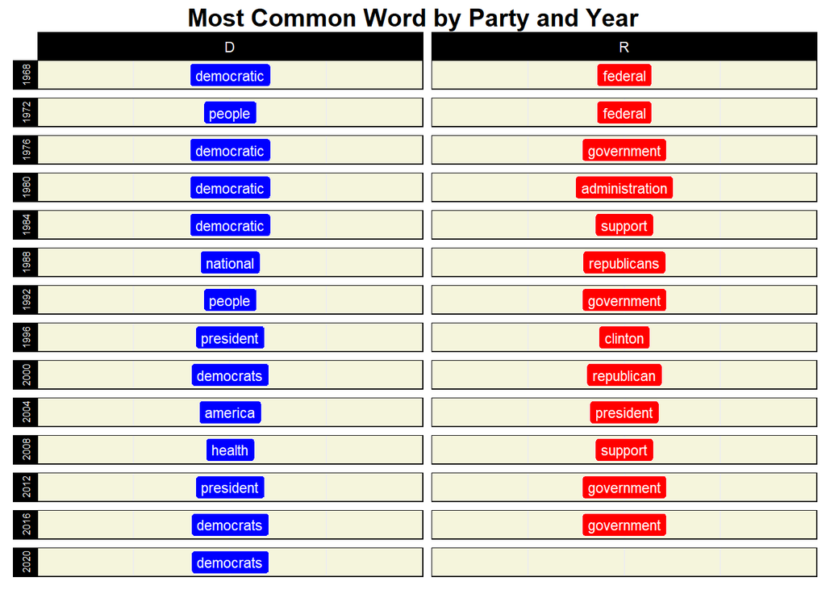

```r
platform_scale <- c(D = "blue", R = "red")
overall %>%
    count(party, year, word) %>%
    group_by(party, year) %>%
    slice_max(order_by = n, n = 1) %>%
    ggplot() + geom_label(aes(x = 1, y = 1, label = word, fill = party), col = "white", size = 3) + scale_fill_manual(values = platform_scale) +
    labs(title = "Most Common Word by Party and Year") + facet_grid(year ~ party, switch = "y") + theme(axis.text = element_blank(),
    axis.title = element_blank(), axis.ticks = element_blank(), strip.text.y = element_text(angle = 90,
        size = 6), panel.background = element_rect(fill = "beige"), legend.position = "none")
```

I turn to the related question of how word count varies by year.

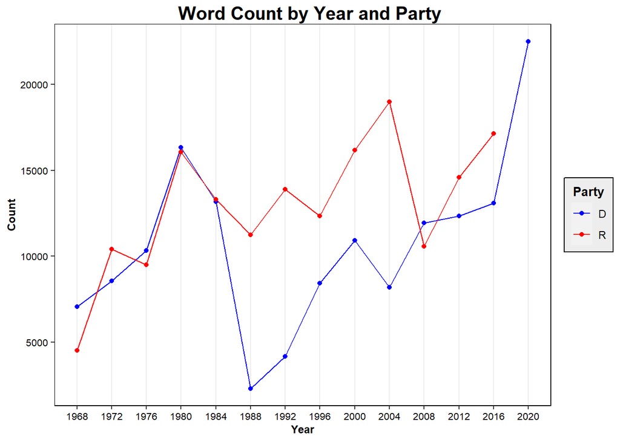

```r
year_scale <- partial(scale_x_continuous, breaks = seq(1968, 2020, by = 4), ... = )

overall %>%
    count(party, year) %>%
    ggplot(aes(x = year, y = n, col = party)) + year_scale() + geom_line() + geom_point() + scale_color_manual(values = platform_scale) +
    labs(title = "Word Count by Year and Party", color = "Party", x = "Year", y = "Count")
```

## tf-idf

Term frequency-inverse document frequency measures a term’s commonness in one document relative to other documents. It assumes that words that are unusually common in certain documents convey significant meaning. In this corpus, the terms with the highest tf-idf were mostly the names of one of the two candidates, either from the same party or the opposing one. This makes sense; most of those names would only be topical in one election cycle. The “cent” in the Democratic platform of 1976 comes from rendering “percent” as two words. No idea why 2008 for Republicans is “lawyers,” however.

```r
overall %>%
    count(word, party_year) %>%
    bind_tf_idf(term = word, document = party_year, n = n) %>%
    group_by(party_year) %>%
    slice_max(order_by = tf_idf, n = 1) %>%
    arrange(party_year) %>%
    knitr::kable()
```

| word | party_year | n | tf | idf | tf_idf |
| --- | --- | --- | --- | --- | --- |
| johnson | D1968 | 10 | 0.0014180 | 1.5040774 | 0.0021328 |
| nixon | D1972 | 46 | 0.0053807 | 1.5040774 | 0.0080931 |
| cent | D1976 | 14 | 0.0013562 | 1.9095425 | 0.0025897 |
| carter | D1980 | 33 | 0.0020219 | 0.9932518 | 0.0020083 |
| reagan | D1984 | 128 | 0.0097250 | 0.7308875 | 0.0071079 |
| coast | D1988 | 5 | 0.0021711 | 0.8979416 | 0.0019495 |
| twelve | D1992 | 6 | 0.0014430 | 1.5040774 | 0.0021704 |
| clinton | D1996 | 105 | 0.0124452 | 1.0986123 | 0.0136724 |
| gore | D2000 | 97 | 0.0088779 | 2.1972246 | 0.0195068 |
| edwards | D2004 | 21 | 0.0025616 | 3.2958369 | 0.0084426 |
| barack | D2008 | 8 | 0.0006704 | 2.6026897 | 0.0017447 |
| obama | D2012 | 122 | 0.0098922 | 1.5040774 | 0.0148786 |
| donald | D2016 | 30 | 0.0022915 | 2.6026897 | 0.0059640 |
| trump | D2020 | 90 | 0.0040020 | 2.6026897 | 0.0104159 |
| anew | R1968 | 11 | 0.0024309 | 1.2163953 | 0.0029570 |
| cent | R1972 | 32 | 0.0030754 | 1.9095425 | 0.0058727 |
| democrat | R1976 | 35 | 0.0036827 | 0.8979416 | 0.0033068 |
| carter | R1980 | 112 | 0.0069730 | 0.9932518 | 0.0069259 |
| mondale | R1984 | 52 | 0.0039107 | 2.1972246 | 0.0085926 |
| reagan | R1988 | 67 | 0.0059561 | 0.7308875 | 0.0043532 |
| democrat | R1992 | 58 | 0.0041733 | 0.8979416 | 0.0037473 |
| clinton | R1996 | 111 | 0.0089886 | 1.0986123 | 0.0098750 |
| governor | R2000 | 26 | 0.0016094 | 1.2163953 | 0.0019577 |
| bush | R2004 | 176 | 0.0092788 | 0.5232481 | 0.0048551 |
| lawyers | R2008 | 9 | 0.0008520 | 0.8979416 | 0.0007650 |
| healthcare | R2012 | 32 | 0.0021925 | 2.1972246 | 0.0048175 |
| healthcare | R2016 | 28 | 0.0016335 | 2.1972246 | 0.0035892 |

There is surprising variation in word frequency rank distribution, with the longer platforms having more variety.

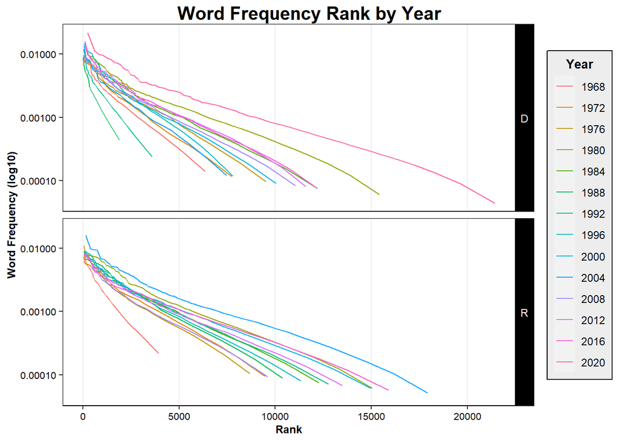

```r
overall %>%
    mutate(across(c(party, year), as.factor)) %>%
    group_by(party_year) %>%
    add_count(word) %>%
    mutate(freq = n/n(), rank = rank(-freq)) %>%
    ungroup() %>%
    arrange(desc(freq)) %>%
    ggplot(aes(x = rank, y = freq, col = year)) + geom_line() + facet_grid(party ~ ., scales = "free_x") +
    scale_y_log10(labels = scales::label_number()) + labs(title = "Word Frequency Rank by Year", x = "Rank",
    y = "Word Frequency (log10)", color = "Year")
```

# Sentiment Analysis

## Overall

Sentiment analysis associates words, sentences, or other tokens with positive or negative sentiment, coded as either a binary or ordinal representation. I will use the AFINN lexicon, which scores sentiment from -5 (most negative) to 5 (most positive).

Average sentiment in most party-years was mildly positive, with no year above 1. The outlier is 1972, with a far more positive Republican than Democratic platform. That is not what we’d expect from a comparison of second-term Nixon and George McGovern, which might indicate a problem with the approach.

```r
library(lubridate)
word_sentiments <- overall %>%
    inner_join(get_sentiments("afinn"))
sent_sentiments <- word_sentiments %>%
    group_by(party, year, sentence) %>%
    summarize(`AFINN Mean` = mean(value)) %>%
    mutate(sen_number = seq_len(n())) %>%
    ungroup()
sent_means <- sent_sentiments %>%
    group_by(party, year) %>%
    summarize(`AFINN Mean` = mean(`AFINN Mean`)) %>%
    ungroup()
```

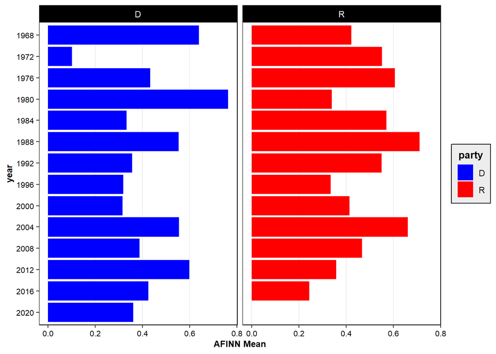

```r
sent_means %>%
    mutate(year = fct_rev(fct_inseq(as_factor(year)))) %>%
    ggplot(aes(x = year, y = `AFINN Mean`, fill = party)) + geom_col() + scale_fill_manual(values = platform_scale) +
    coord_flip() + facet_grid(. ~ party)
```

The difference in means by party is nowhere near significant, however.

```r
word_sentiments %>%
    filter(year != "2020") %>%
    t.test(value ~ party, data = ., alternative = "two.sided", var.eqal = FALSE) %>%
    tidy() %>%
    knitr::kable()
```

| estimate | estimate1 | estimate2 | statistic | p.value | parameter | conf.low | conf.high | method | alternative |
| --- | --- | --- | --- | --- | --- | --- | --- | --- | --- |
| -0.0117106 | 0.4188606 | 0.4305712 | -0.6874858 | 0.4917805 | 41965.61 | -0.0450977 | 0.0216764 | Welch Two Sample t-test | two.sided |

In most years, the Republican platform was more positive overall.

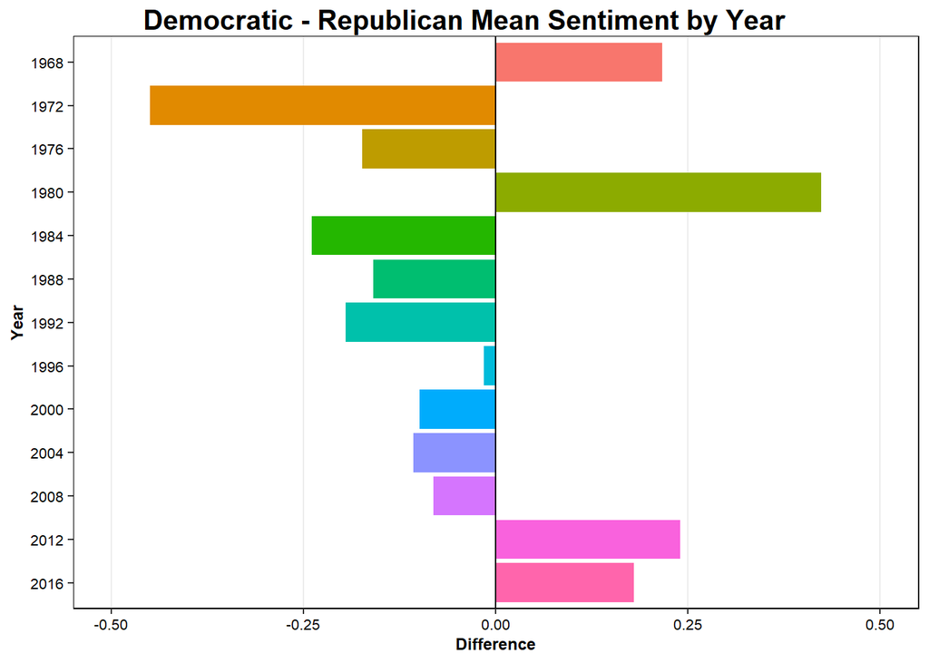

```r
sent_means %>%
    group_by(year) %>%
    summarize(diff = `AFINN Mean`[party == "D"] - `AFINN Mean`[party == "R"]) %>%
    ggplot(aes(x = fct_reorder(factor(year), rev(sort(year))), y = diff, fill = factor(year))) + geom_col() +
    geom_hline(yintercept = 0, col = "black") + ylim(c(-0.5, 0.5)) + coord_flip() + labs(title = "Democratic - Republican Mean Sentiment by Year",
    x = "Year", y = "Difference") + theme(legend.position = "none")
```

## Sentence by Sentence

Let’s compare the sentence-by-sentence sentiment of the platforms in 1972, the year of greatest difference. For each sentence, I take the mean of the AFINN scores for each word to establish an average sentiment. This is easy enough, though it underrates the importance of long sentences. Here, it seems the Democratic platform has more varying sentiment.

It also seems no sentence in one platform ever recurs in another.

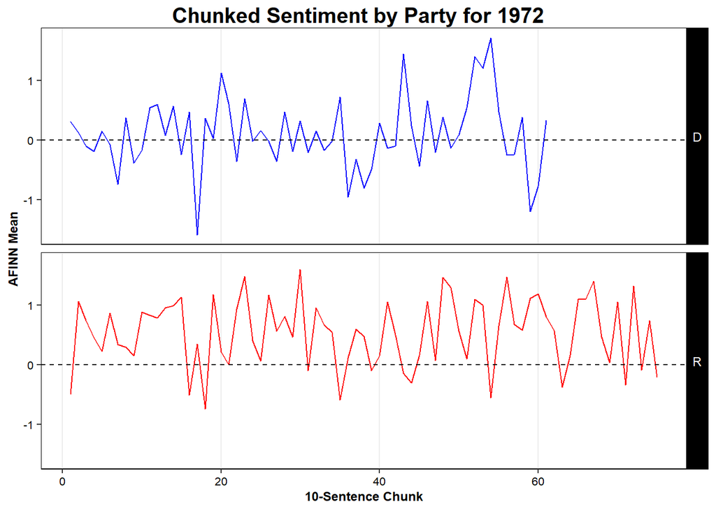

```r
agg <- 10
sent_sentiments %>%
    mutate(sen_number = (sen_number%/%agg) + 1) %>%
    group_by(sen_number, party, year) %>%
    summarize(`AFINN Mean` = mean(`AFINN Mean`)) %>%
    ungroup() %>%
    filter(year == 1972) %>%
    ggplot(aes(x = sen_number, y = `AFINN Mean`, col = factor(party))) + geom_line() + scale_color_manual(values = platform_scale) +
    geom_hline(yintercept = 0, linetype = "dashed") + facet_grid(rows = party ~ .) + labs(title = "Chunked Sentiment by Party for 1972",
    x = "10-Sentence Chunk") + theme(legend.position = "none")
```

## By Passage

Which passages had the most extreme sentiment scores? I filter for the highest and lowest AFINN score means. The most negative passage of all castigates Bill Clinton for vetoing the partial-birth abortion ban; the most positive seems to be a 1984 Republican section extolling Reagan’s policy successes. From these results, the coding scheme seems sound.

```r
sent_sentiments %>%
    mutate(sen_number = (sen_number%/%agg) + 1) %>%
    group_by(sen_number, party, year) %>%
    summarize(sen_number = unique(sen_number), sentence = paste(sentence, collapse = " "), `AFINN Mean` = mean(`AFINN Mean`)) %>%
    ungroup() %>%
    group_by(year) %>%
    filter(`AFINN Mean` %in% range(`AFINN Mean`[year == year])) %>%
    arrange(-abs(`AFINN Mean`)) %>%
    dplyr::select(`AFINN Mean`, everything())
```

```
# A tibble: 29 x 5
# Groups:   year [14]
   `AFINN Mean` sen_number party  year sentence
          <dbl>      <dbl> <chr> <dbl> <chr>
 1        -2.5          88 R      1996 worse vetoed ban partial birth abortions procedure denounced~
 2         1.93         31 R      1984 encourage closer ties countries south america strengthening ~
 3         1.88         42 D      1968 support extension neighborhood centers support farmers barga~
 4         1.88        103 R      2000 support efforts ensure equitable participation federal progr~
 5         1.85         98 R      2004 republicans congress strongly supported president's plan rep~
 6         1.8          93 R      1992 study prepared urban institute mandate require federal taxes~
 7         1.79         68 R      2008 support law prohibiting gambling internet support level inve~
 8         1.77         28 R      1976 friendship african countries expressed support continued pea~
 9         1.77         50 R      1976 relations united americas vital importance removal counter p~
10        -1.75         95 D      1984 workers industries displaced unfair import competition irrat~
# ... with 19 more rows
```

# By Incumbency

What fraction of words in each platform is positive? In incumbent years, it seems the party defending the White House adopts a more positive tone than the challenging party.

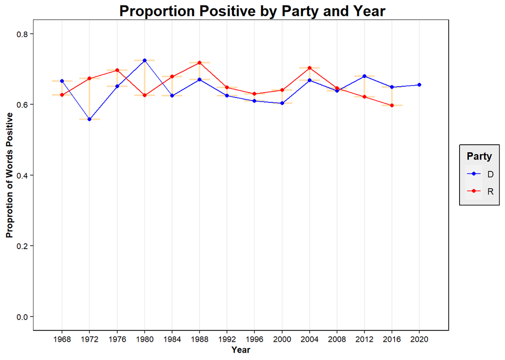

```r
word_sentiments %>%
    mutate(value = ifelse(value <= 0, 0, 1)) %>%
    group_by(year, party) %>%
    summarize(`Proportion Positive` = mean(value)) %>%
    mutate(mins = c(pmin(`Proportion Positive`[party == "R"], `Proportion Positive`[party == "D"]), NA),
        maxes = c(pmax(`Proportion Positive`[party == "R"], `Proportion Positive`[party == "D"]), NA)) %>%
    ungroup() %>%
    ggplot(aes(x = year, y = `Proportion Positive`, col = party)) + scale_color_manual(values = platform_scale) +
    geom_errorbar(aes(xend = year, ymin = mins, ymax = maxes), col = "navajowhite", width = 3, size = 0.75) +
    geom_point() + scale_x_continuous(breaks = seq(1968, 2020, by = 4)) + geom_line() + ylim(c(0, 0.8)) +
    labs(title = "Proportion Positive by Party and Year", x = "Year", y = "Proprotion of Words Positive",
        col = "Party")
```

If we split platforms by the party defending and compare mean sentiments, they are almost identical, consistent with the party’s defending/contesting position determining its stance.

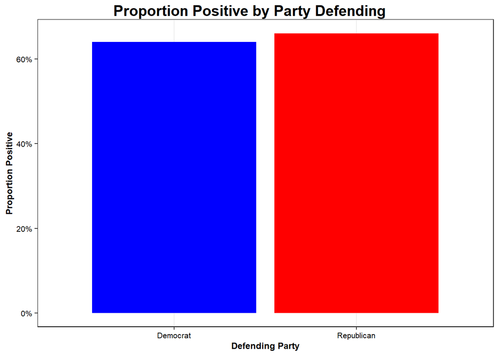

```r
d_defend <- c(1968, 1980, 1996, 2000, 2012, 2016)
r_defend <- setdiff(overall$year, d_defend)
by_defender <- word_sentiments %>%
    mutate(value = ifelse(value <= 0, 0, 1), defender = if_else(year %in% d_defend, "Democrat", "Republican") %>%
        as_factor())

by_defender %>%
    group_by(defender) %>%
    summarize(`Proportion Positive` = mean(value)) %>%
    ggplot(aes(x = defender, y = `Proportion Positive`, fill = defender)) + geom_col() + scale_fill_manual(values = set_names(platform_scale,
    nm = NULL)) + scale_x_discrete(expand = c(0, 0.75)) + scale_y_continuous(labels = scales::percent_format()) +
    labs(title = "Proportion Positive by Party Defending", x = "Defending Party", y = "Proportion Positive",
        fill = "Defending Party") + theme(legend.position = "none")
```

Mean positivity for defending parties was about 4% higher than for challengers. A difference-of-means test confirms the difference is significant, though not very substantial.

```r
by_defender %>%
    mutate(challenging = if_else((defender == "Republican" & party == "D") | defender == "Democrat" &
        party == "R", "Challenging", "Defending") %>%
        as_factor()) %>%
    t.test(data = ., value ~ challenging, alternative = "less", var.equal = FALSE)
```

```
    Welch Two Sample t-test

data:  value by challenging
t = -9.5437, df = 47730, p-value < 0.00000000000000022
alternative hypothesis: true difference in means is less than 0
95 percent confidence interval:
        -Inf -0.03441384
sample estimates:
mean in group Challenging   mean in group Defending
                0.6309050                 0.6724854
```

```r
anov <- word_sentiments %>%
    mutate(year = fct_reorder(factor(year), rev(sort(year)))) %>%
    aov(data = ., value ~ year)
summary(anov)
```

```
               Df Sum Sq Mean Sq F value              Pr(>F)
year           13    589   45.30   14.34 <0.0000000000000002 ***
Residuals   47720 150697    3.16
---
Signif. codes:  0 '***' 0.001 '**' 0.01 '*' 0.05 '.' 0.1 ' ' 1
```

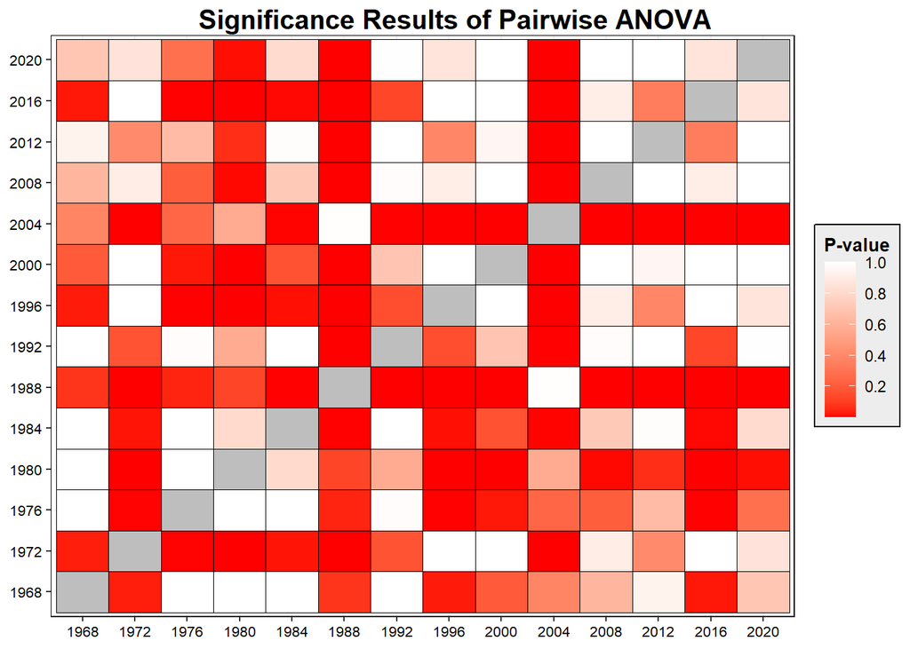

```r
tab <- TukeyHSD(anov) %>%
    purrr::pluck("year") %>%
    as.data.frame() %>%
    rownames_to_column() %>%
    separate(rowname, sep = "-", into = c("yr1", "yr2")) %>%
    mutate(across(starts_with("yr"), as.numeric)) %>%
    {
        rbind(., rename(., c(yr1 = "yr2", yr2 = "yr1")))
    }

grid <- expand_grid(yr1 = full_seq(tab$yr2, period = 4), yr2 = full_seq(tab$yr2, period = 4))
grid %>%
    left_join(tab) %>%
    mutate(across(starts_with("yr"), as.character)) %>%
    ggplot(aes(x = yr1, y = yr2, fill = `p adj`)) + geom_tile(col = "black") + scale_fill_gradient(low = "red",
    high = "white", name = "P-value", na.value = "grey", breaks = c(0, 0.2, 0.4, 0.6, 0.8, 1)) + theme(axis.title = element_blank()) +
    labs(title = "Significance Results of Pairwise ANOVA")
```

# Topic Analysis

Topic modeling attempts to extract the underlying structure of the corpus. It searches for words that commonly co-occur and develops topics that contain differing probabilities of each word. It produces two statistics: $\beta$, a word’s probability of appearing by topic, and $\gamma$, a document’s probability of containing a topic.

## By Party

Does a two-topic model capture variation by party? I count words by party and try a model with two topics. The second topic appears more Republican, though “Democrats” appears in both. Overall, the difference isn’t striking enough to be persuasive.

```r
library(topicmodels)
library(tidytext)

p_dtm <- overall %>%
    mutate(across(c(party, year), as.factor)) %>%
    group_by(party) %>%
    add_count(word) %>%
    cast_dtm(term = word, document = party, value = n)

topics_p <- LDA(p_dtm, k = 2)
```

```r
topics_p %>%
    tidy() %>%
    group_by(topic) %>%
    slice_max(n = 20, order_by = beta)
```

```
# A tibble: 40 x 3
# Groups:   topic [2]
   topic term          beta
   <int> <chr>        <dbl>
 1     1 people     0.0118
 2     1 federal    0.00832
 3     1 americans  0.00766
 4     1 american   0.00719
 5     1 united     0.00640
 6     1 support    0.00558
 7     1 democratic 0.00554
 8     1 party      0.00525
 9     1 tax        0.00507
10     1 efforts    0.00504
# ... with 30 more rows
```

## By Year

```r
y_dtm <- overall %>%
    mutate(across(c(party, year), as.factor)) %>%
    group_by(year) %>%
    add_count(word) %>%
    cast_dtm(term = word, document = year, value = n)

topics_y <- LDA(y_dtm, k = 14, control = list(seed = 54321))


topics_y %>%
    tidy() %>%
    group_by(topic) %>%
    slice_max(n = 20, order_by = beta)
```

```
# A tibble: 281 x 3
# Groups:   topic [14]
   topic term          beta
   <int> <chr>        <dbl>
 1     1 government 0.00963
 2     1 support    0.00797
 3     1 federal    0.00762
 4     1 policy     0.00625
 5     1 programs   0.00615
 6     1 national   0.00595
 7     1 economic   0.00585
 8     1 united     0.00540
 9     1 american   0.00530
10     1 energy     0.00514
# ... with 271 more rows
```

Average beta by topic for the year-topic model. A higher value indicates fewer distinct words.

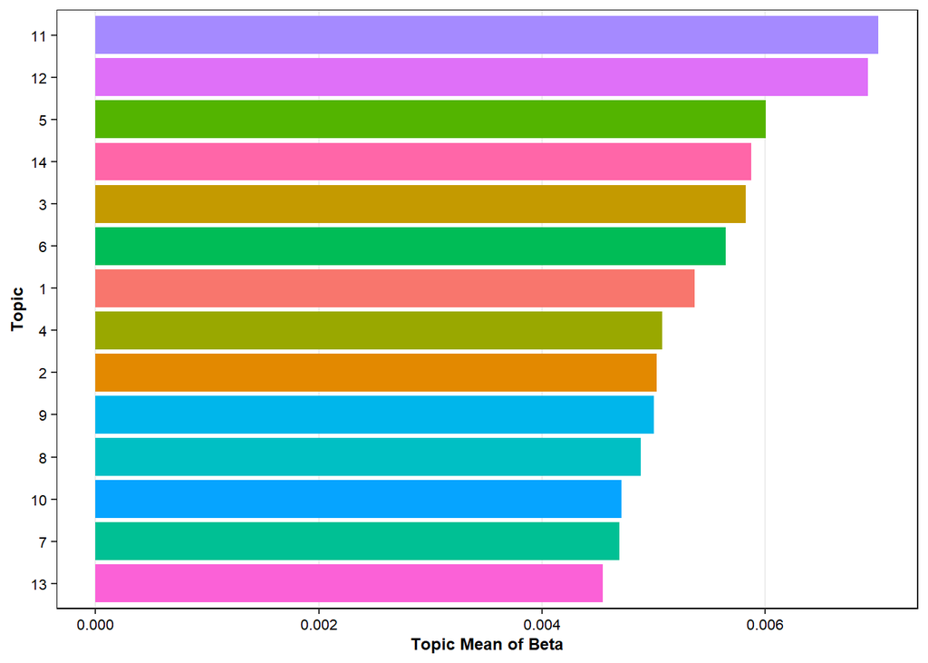

```r
topics_y %>%
    tidy() %>%
    group_by(topic) %>%
    slice_max(n = 20, order_by = beta) %>%
    summarize(beta_mean = mean(beta)) %>%
    ggplot(aes(x = fct_reorder(factor(topic), beta_mean), y = beta_mean, fill = factor(topic))) + geom_col() +
    coord_flip() + labs(y = "Topic Mean of Beta", x = "Topic") + theme(legend.position = "none")
```

```r
topics_y %>%
    tidy() %>%
    filter(topic == 6) %>%
    arrange(-beta) %>%
    slice_max(n = 20, order_by = beta)
```

```
# A tibble: 20 x 3
   topic term              beta
   <int> <chr>            <dbl>
 1     6 federal        0.00773
 2     6 administration 0.00752
 3     6 economic       0.00720
 4     6 government     0.00646
 5     6 policy         0.00639
 6     6 democratic     0.00627
 7     6 party          0.00625
 8     6 programs       0.00603
 9     6 energy         0.00598
10     6 soviet         0.00578
11     6 support        0.00561
12     6 american       0.00554
13     6 republican     0.00526
14     6 republicans    0.00463
15     6 national       0.00456
16     6 united         0.00454
17     6 carter         0.00453
18     6 continue       0.00422
19     6 people         0.00421
20     6 security       0.00419
```

Sure enough, the topic contains several of the top 20 words of 1980 and 1976.

```r
overall %>%
    count(word, year) %>%
    bind_tf_idf(term = word, document = year, n = n) %>%
    inner_join(topics_y %>%
        tidy() %>%
        filter(topic == 6) %>%
        arrange(-beta) %>%
        slice_max(n = 20, order_by = beta), by = c(word = "term")) %>%
    group_by(word) %>%
    arrange(-tf) %>%
    slice_max(n = 1, order_by = tf) %>%
    ungroup() %>%
    count(year) %>%
    arrange(-n)
```

```
# A tibble: 8 x 2
   year     n
  <dbl> <int>
1  1980     6
2  1976     4
3  1984     2
4  1988     2
5  1996     2
6  2020     2
7  1968     1
8  2012     1
```

It looks like the year-topic correspondence did the worst for the 1980s but performed well in other years. Perhaps there was less variation that decade because Republicans controlled the presidency for almost all of it?

```r
year_gamma <- tidy(topics_y, matrix = "gamma")
year_gamma %>%
    group_by(document) %>%
    slice_max(n = 1, order_by = gamma) %>%
    arrange(document)
```

```
# A tibble: 14 x 3
# Groups:   document [14]
   document topic gamma
   <chr>    <int> <dbl>
 1 1968         2 1.00
 2 1972         8 1.00
 3 1976         1 1.00
 4 1980         6 0.811
 5 1984         5 0.588
 6 1988         5 0.501
 7 1992         9 1.00
 8 1996        14 1.00
 9 2000        13 0.948
10 2004         3 1.00
11 2008         4 0.981
12 2012        10 0.999
13 2016         7 1.00
14 2020        11 1.00
```

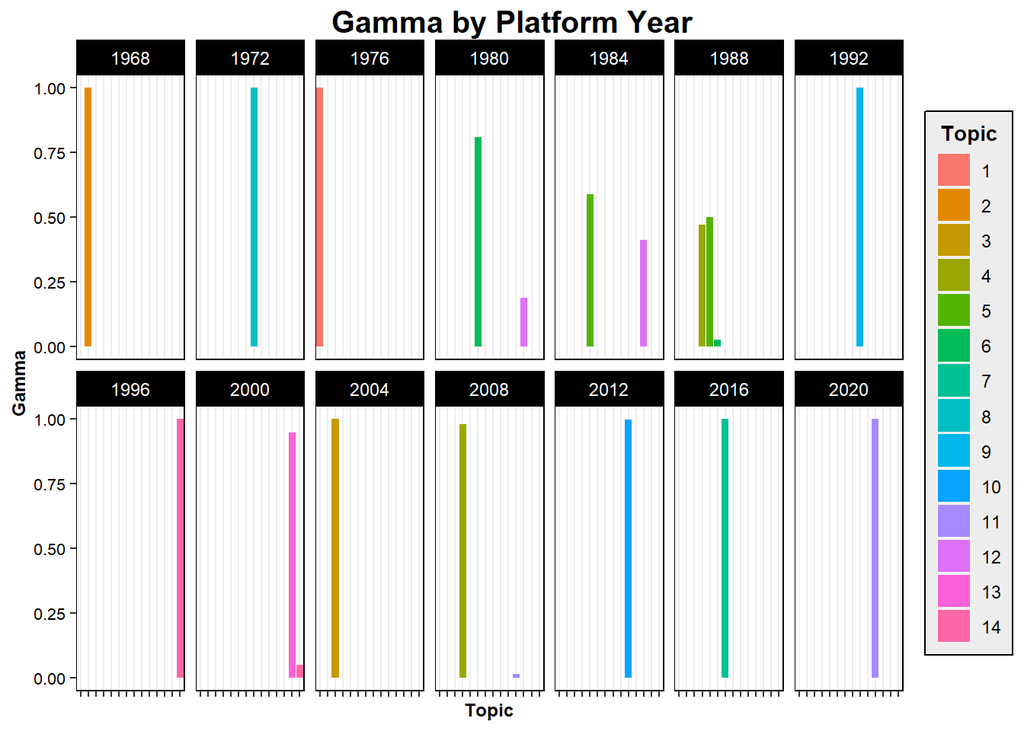

```r
year_gamma %>%
    ggplot(aes(x = factor(topic), y = gamma, fill = factor(topic))) + geom_col() + theme(axis.text.x = element_blank()) +
    facet_wrap(document ~ ., nrow = 2) + labs(y = "Gamma", x = "Topic", title = "Gamma by Platform Year",
    scales = "free_x", fill = "Topic")
```

Another way of visualizing the pattern. 1984 and 1988 are the only years that aren’t predominantly associated with one topic.

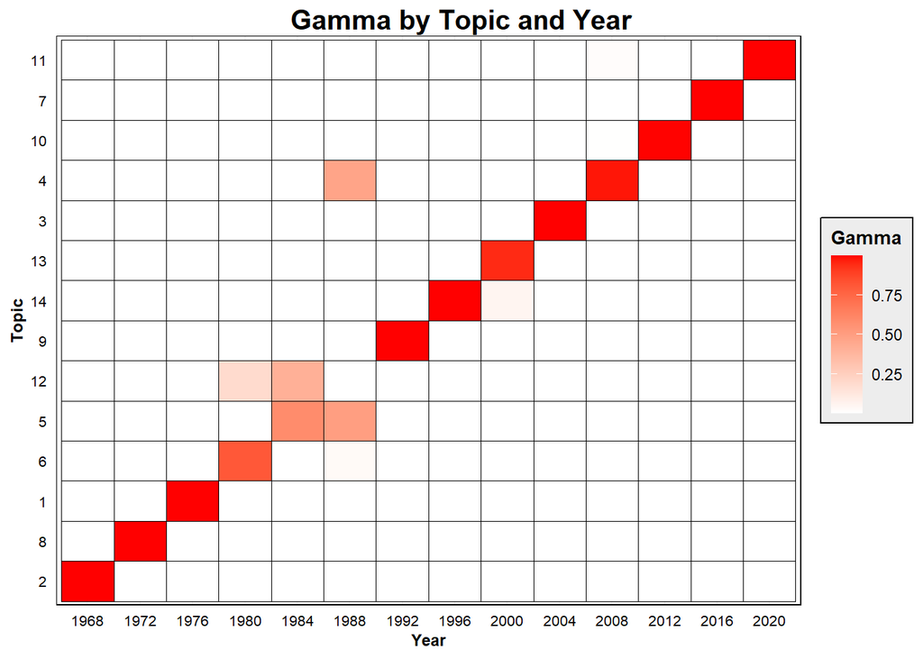

```r
ord <- topics_y %>%
    tidy(matrix = "gamma") %>%
    group_by(topic) %>%
    slice_max(n = 1, order_by = gamma) %>%
    arrange(document) %>%
    pull(topic)
topics_y %>%
    tidy(matrix = "gamma") %>%
    ggplot(aes(x = factor(document), y = factor(topic, ordered = TRUE, levels = ord), fill = gamma)) +
    geom_tile(color = "black") + scale_fill_gradient(low = "white", high = "red") + labs(title = "Gamma by Topic and Year",
    x = "Year", y = "Topic", fill = "Gamma") + theme(axis.ticks = element_blank())
```

## By Word

Which words were most consistent among topics? Not surprisingly, generic ones relating politics. “American” is among the top 20 words in all fourteen topics.

```r
topics_y %>%
    tidy(matrix = "beta") %>%
    group_by(topic) %>%
    slice_max(n = 20, order_by = beta) %>%
    left_join(year_gamma, ., by = c("topic")) %>%
    count(term, topic) %>%
    count(term, wt = n) %>%
    mutate(n = n/14) %>%
    arrange(-n)
```

```
# A tibble: 73 x 2
   term           n
   <chr>      <dbl>
 1 american      14
 2 people        13
 3 support       13
 4 government    12
 5 federal       11
 6 americans     10
 7 national       9
 8 care           8
 9 economic       8
10 public         8
# ... with 63 more rows
```

Let’s compare the top 10 words among each topic. A handful are shared among almost all topics, but some are common only to a few.

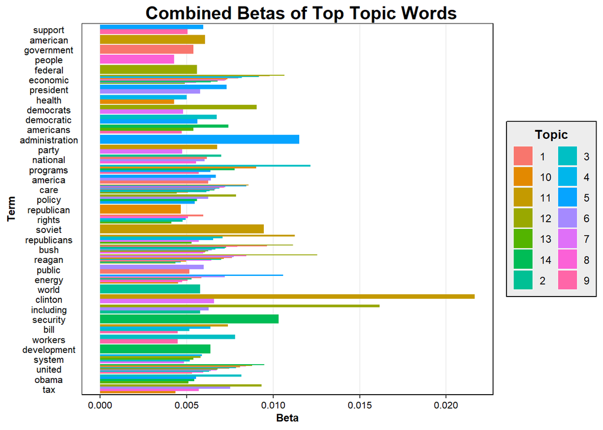

```r
topic_words <- topics_y %>%
    tidy(matrix = "beta") %>%
    group_by(topic) %>%
    slice_max(n = 10, order_by = beta) %>%
    ungroup()

# ggplot(data = topic_words %>% mutate(term = fct_reorder(factor(term), beta, sum)))+ topic_words %>%
# mutate(term = fct_reorder(factor(term), beta, sum)) %>% split(.$term) %>% {.[rev(order(map_dbl(.,
# ~sum(.x$beta))))]} %>% map(~geom_col(data = .x, position = 'dodge', aes(x= factor(term), y =beta,
# fill = fct_reorder(factor(topic), beta)))) + coord_flip() + #scale_x_discrete(labels =
# levels(fct_reorder(factor(topic_words$term), topic_words$beta, sum))) labs(title = 'Combined Betas
# of Top Topic Words', x = 'Term', y = 'Beta', fill = 'Topic')

topic_words %>%
    ggplot(aes(x = fct_reorder(factor(term), beta, sum), y = beta, fill = factor(topic))) + (topic_words %>%
    mutate(term = fct_reorder(factor(term), beta, sum)) %>%
    split(.$term) %>%
    {
        .[rev(order(map_dbl(., ~sum(.x$beta))))]
    } %>%
    map(~geom_col(data = .x, position = "dodge", aes(x = factor(term), y = beta, fill = fct_reorder(factor(topic),
        beta))))) + coord_flip() + scale_x_discrete(labels = levels(fct_reorder(factor(topic_words$term),
    topic_words$beta, sum))) + coord_flip() + theme(axis.ticks.y = element_blank(), axis.text.y = element_text(size = 8)) +
    labs(title = "Combined Betas of Top Topic Words", x = "Term", y = "Beta", fill = "Topic") + guides(fill = guide_legend(ncol = 2))
```

Which of each topic’s most common words had the lowest betas in other topics? It appears variants of “democrat” were used much more in some years than in others.

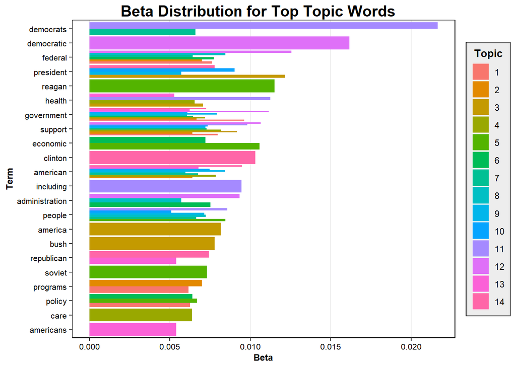

```r
topics_y %>%
    tidy(matrix = "beta") %>%
    group_by(topic) %>%
    slice_max(n = 5, order_by = beta) %>%
    ungroup() %>%
    split(.$term) %>%
    map(~arrange(.x, -beta)) %>%
    bind_rows() %>%
    ggplot(aes(x = fct_reorder(factor(term), beta, max), y = beta, fill = factor(topic))) + geom_col(position = "dodge") +
    coord_flip() + labs(x = "Term", y = "Beta", fill = "Topic", title = "Beta Distribution for Top Topic Words")
```

# Conclusion

Party platforms varied strongly by year, and a one-topic-per-year model differentiated them clearly. Democratic and Republican platforms overall were fairly similar. The most commonly used words tended to be generic (“American”, “Support”, etc.), but many platforms contained words common only in that year (often the names of candidates). Average platform sentiment was mildly positive overall, significantly more so for the incumbent’s party. Many further insights into American political history could be gleaned by deeper analysis of party platforms.